# Bander-Ohoud-python project-2019-Copy1

## AirBnB Project

_Author: Ohoud Rehbini

#### Library varification

##### Open the data as `pandas` Dataframes:

```python
import pandas as pd
import numpy as np
airbnb = pd.read_csv('AirBnB.csv')
from matplotlib import pyplot as plt
import warnings
warnings.filterwarnings("ignore")
%matplotlib inline

# Change pandas viewing options
pd.set_option('display.max_rows', 500)
pd.set_option('display.max_columns', 500)
pd.set_option('display.width', 1000)
```

```python
import seaborn as sns
```

## 1. Review the Data:

```python
airbnb.shape # shows 3723 rows and 64 col
```

```
(3723, 64)
```

```python
airbnb.info(max_cols=20)
```

```
<class 'pandas.core.frame.DataFrame'>
RangeIndex: 3723 entries, 0 to 3722
Columns: 64 entries, id to review_scores_value
dtypes: float64(13), int64(13), object(38)
memory usage: 1.8+ MB
```

## 2.Cleaning Data :

### ○ Are all the columns useful to our analysis?

#### we dont need all these columns in our statstics :

```python
col_to_drop = ['space','summary','host_url','host_since','host_id','host_location','host_about',
               'host_response_time','host_response_rate',
               'host_acceptance_rate','host_is_superhost',
               'host_thumbnail_url','host_picture_url',
               'host_has_profile_pic','host_identity_verified',
               'zipcode','market','country_code','latitude',
               'longitude','is_location_exact','bathrooms',
               'bedrooms','beds','square_feet','security_deposit',
               'cleaning_fee','calendar_updated','has_availability',
               'availability_30','availability_60','availability_90',
               'availability_365','calendar_last_scraped']
airbnb.drop(col_to_drop , axis=1, inplace=True)
```

```python
airbnb.columns #print the columns of data
```

```
Index(['id', 'name', 'host_name', 'host_neighbourhood', 'host_listings_count', 'host_total_listings_count', 'street', 'neighbourhood', 'city', 'state', 'property_type', 'room_type', 'accommodates', 'price', 'weekly_price', 'monthly_price', 'guests_included', 'extra_people', 'minimum_nights', 'maximu…
```

```python
airbnb.info(max_cols=20)
```

```
<class 'pandas.core.frame.DataFrame'>
RangeIndex: 3723 entries, 0 to 3722
Columns: 30 entries, id to review_scores_value
dtypes: float64(7), int64(8), object(15)
memory usage: 872.7+ KB
```

```python
airbnb.describe(include='all')
```

|  | id | name | host_name | host_neighbourhood | host_listings_count | host_total_listings_count | street | neighbourhood | city | state | property_type | room_type | accommodates | price | weekly_price | monthly_price | guests_included | extra_people | minimum_nights | maximum_nights | number_of_reviews | first_review | last_review | review_scores_rating | review_scores_accuracy | review_scores_cleanliness | review_scores_checkin | review_scores_communication | review_scores_location | … |
| --- | --- | --- | --- | --- | --- | --- | --- | --- | --- | --- | --- | --- | --- | --- | --- | --- | --- | --- | --- | --- | --- | --- | --- | --- | --- | --- | --- | --- | --- | --- |
| count | 3.723000e+03 | 3723 | 3723 | 3461 | 3723.000000 | 3723.000000 | 3723 | 3370 | 3723 | 3723 | 3722 | 3723 | 3723.000000 | 3723 | 2124 | 1807 | 3723.000000 | 3723 | 3723.000000 | 3.723000e+03 | 3723.000000 | 2893 | 2893 | 2855.00000 | 2848.000000 | 2847.000000 | 2847.000000 | 2851.000000 | 2851.000000 | … |
| unique | NaN | 3693 | 1549 | 131 | NaN | NaN | 1145 | 102 | 16 | 5 | 11 | 3 | NaN | 284 | 439 | 447 | NaN | 48 | NaN | NaN | NaN | 924 | 336 | NaN | NaN | NaN | NaN | NaN | NaN | … |
| top | NaN | The HUB at Capitol Hill | Seamless | Capitol Hill | NaN | NaN | 16th Street Northwest, Washington, DC 20009, U... | Capitol Hill | Washington | DC | Apartment | Entire home/apt | NaN | $100.00 | $600.00 | $2,500.00 | NaN | $0.00 | NaN | NaN | NaN | 9/21/15 | 9/21/15 | NaN | NaN | NaN | NaN | NaN | NaN | … |
| freq | NaN | 4 | 62 | 300 | NaN | NaN | 54 | 339 | 3628 | 3696 | 2259 | 2419 | NaN | 167 | 115 | 60 | NaN | 2129 | NaN | NaN | NaN | 34 | 150 | NaN | NaN | NaN | NaN | NaN | NaN | … |
| mean | 4.798778e+06 | NaN | NaN | NaN | 13.517325 | 13.517325 | NaN | NaN | NaN | NaN | NaN | NaN | 3.195004 | NaN | NaN | NaN | 1.622079 | NaN | 2.250067 | 5.803069e+05 | 15.306742 | NaN | NaN | 93.42627 | 9.540730 | 9.330875 | 9.710924 | 9.752718 | 9.386180 | … |
| std | 2.639497e+06 | NaN | NaN | NaN | 64.534408 | 64.534408 | NaN | NaN | NaN | NaN | NaN | NaN | 2.012216 | NaN | NaN | NaN | 1.348598 | NaN | 3.622879 | 3.519552e+07 | 29.645586 | NaN | NaN | 7.77311 | 0.790103 | 1.050435 | 0.672492 | 0.605433 | 0.890065 | … |
| min | 3.192000e+03 | NaN | NaN | NaN | 1.000000 | 1.000000 | NaN | NaN | NaN | NaN | NaN | NaN | 1.000000 | NaN | NaN | NaN | 0.000000 | NaN | 1.000000 | 1.000000e+00 | 0.000000 | NaN | NaN | 30.00000 | 2.000000 | 2.000000 | 2.000000 | 3.000000 | 4.000000 | … |
| 25% | 2.482238e+06 | NaN | NaN | NaN | 1.000000 | 1.000000 | NaN | NaN | NaN | NaN | NaN | NaN | 2.000000 | NaN | NaN | NaN | 1.000000 | NaN | 1.000000 | 1.200000e+02 | 1.000000 | NaN | NaN | 90.00000 | 9.000000 | 9.000000 | 10.000000 | 10.000000 | 9.000000 | … |
| 50% | 5.002566e+06 | NaN | NaN | NaN | 1.000000 | 1.000000 | NaN | NaN | NaN | NaN | NaN | NaN | 2.000000 | NaN | NaN | NaN | 1.000000 | NaN | 2.000000 | 1.125000e+03 | 4.000000 | NaN | NaN | 95.00000 | 10.000000 | 10.000000 | 10.000000 | 10.000000 | 10.000000 | … |
| 75% | 7.148024e+06 | NaN | NaN | NaN | 3.000000 | 3.000000 | NaN | NaN | NaN | NaN | NaN | NaN | 4.000000 | NaN | NaN | NaN | 2.000000 | NaN | 3.000000 | 1.125000e+03 | 16.000000 | NaN | NaN | 100.00000 | 10.000000 | 10.000000 | 10.000000 | 10.000000 | 10.000000 | … |
| max | 8.688666e+06 | NaN | NaN | NaN | 480.000000 | 480.000000 | NaN | NaN | NaN | NaN | NaN | NaN | 16.000000 | NaN | NaN | NaN | 16.000000 | NaN | 180.000000 | 2.147484e+09 | 362.000000 | NaN | NaN | 100.00000 | 10.000000 | 10.000000 | 10.000000 | 10.000000 | 10.000000 | … |

○ As we see it is end-up with 30 columns out of 64 columns

### Some categorical columns need to be converted into numeric. and strip any sign out of it like $:</h2>

Here an Example of the `price` column which have '$' sign and not numric

```python
airbnb['price'].head()
```

```
0    $160.00
1    $350.00
2     $50.00
3     $95.00
4     $50.00
Name: price, dtype: object
```

```python
def dollars_to_float(value):

    # try to convert the inputted value to a float
    try:
        return float(value.strip('$').rstrip(','))
        #return float(value.replace('$', "").replace(',',""))

    # in the case of the value being a null value, we simply return a null
    except:
        return np.nan


airbnb['price'] = airbnb['price'].apply(dollars_to_float)
airbnb['extra_people'] = airbnb['extra_people'].apply(dollars_to_float)
```

```python
airbnb['price'].head()
```

```
0    160.0
1    350.0
2     50.0
3     95.0
4     50.0
Name: price, dtype: float64
```

### Now we want to see what is the columns with null values needs to be eleminated :

```python
airbnb.isnull().sum()[airbnb.isnull().sum() != 0].sort_values(ascending=False)
```

```
monthly_price                  1916
weekly_price                   1599
review_scores_checkin           876
review_scores_cleanliness       876
review_scores_accuracy          875
review_scores_value             872
review_scores_location          872
review_scores_communication     872
review_scores_rating            868
last_review                     830
first_review                    830
neighbourhood                   353
host_neighbourhood              262
price                            20
property_type                     1
dtype: int64
```

To confirm the `ID` column is unique , we compare it with AirBnb Data:

```python
len(airbnb["id"].unique()) , airbnb.shape
```

```
(3723, (3723, 30))
```

Base on that and business request we decided to drop all nulls in this columns : `number_of_reviews`,`review_scores_value`,`property_type`,`price`

```python
airbnb = airbnb[pd.notnull(airbnb['number_of_reviews'])]
airbnb = airbnb[pd.notnull(airbnb['review_scores_value'])]
airbnb = airbnb[pd.notnull(airbnb['property_type'])]
airbnb = airbnb[pd.notnull(airbnb['price'])]
```

And we don't want make sure `number_of_reviews`,`guests_included`,`price` not equal to zeros. As we see in this Example 85 zeros of `guests_included` that would misslead the statstics.

```python
airbnb[airbnb['guests_included'] ==0].count().head(10)
```

```
id                           85
name                         85
host_name                    85
host_neighbourhood           73
host_listings_count          85
host_total_listings_count    85
street                       85
neighbourhood                68
city                         85
state                        85
dtype: int64
```

```python
airbnb = airbnb[airbnb['number_of_reviews'] !=0]
airbnb = airbnb[airbnb['guests_included'] !=0]
airbnb = airbnb[airbnb['price'] != 0]
```

### Now we see how many rows we still have.

```python
airbnb.shape
```

```
(2764, 30)
```

```python
airbnb.columns
```

```
Index(['id', 'name', 'host_name', 'host_neighbourhood', 'host_listings_count', 'host_total_listings_count', 'street', 'neighbourhood', 'city', 'state', 'property_type', 'room_type', 'accommodates', 'price', 'weekly_price', 'monthly_price', 'guests_included', 'extra_people', 'minimum_nights', 'maximu…
```

```python
airbnb.describe().T
```

|  | count | mean | std | min | 25% | 50% | 75% | max |
| --- | --- | --- | --- | --- | --- | --- | --- | --- |
| id | 2764.0 | 4.196425e+06 | 2.466973e+06 | 3192.0 | 1979314.5 | 4358894.5 | 6294348.25 | 8.596920e+06 |
| host_listings_count | 2764.0 | 1.176809e+01 | 5.958257e+01 | 1.0 | 1.0 | 1.0 | 3.00 | 4.800000e+02 |
| host_total_listings_count | 2764.0 | 1.176809e+01 | 5.958257e+01 | 1.0 | 1.0 | 1.0 | 3.00 | 4.800000e+02 |
| accommodates | 2764.0 | 3.164978e+00 | 1.856094e+00 | 1.0 | 2.0 | 2.0 | 4.00 | 1.600000e+01 |
| price | 2764.0 | 1.339801e+02 | 8.110579e+01 | 20.0 | 85.0 | 111.0 | 150.00 | 9.750000e+02 |
| guests_included | 2764.0 | 1.714182e+00 | 1.297315e+00 | 1.0 | 1.0 | 1.0 | 2.00 | 1.200000e+01 |
| extra_people | 2764.0 | 1.267438e+01 | 2.151232e+01 | 0.0 | 0.0 | 0.0 | 20.00 | 3.000000e+02 |
| minimum_nights | 2764.0 | 2.207308e+00 | 3.912646e+00 | 1.0 | 1.0 | 2.0 | 3.00 | 1.800000e+02 |
| maximum_nights | 2764.0 | 7.813596e+05 | 4.084742e+07 | 1.0 | 90.0 | 1125.0 | 1125.00 | 2.147484e+09 |
| number_of_reviews | 2764.0 | 1.988061e+01 | 3.198836e+01 | 1.0 | 3.0 | 8.0 | 23.00 | 3.620000e+02 |
| review_scores_rating | 2764.0 | 9.346274e+01 | 7.699739e+00 | 30.0 | 90.0 | 95.0 | 100.00 | 1.000000e+02 |
| review_scores_accuracy | 2761.0 | 9.547628e+00 | 7.792571e-01 | 2.0 | 9.0 | 10.0 | 10.00 | 1.000000e+01 |
| review_scores_cleanliness | 2760.0 | 9.342391e+00 | 1.033235e+00 | 2.0 | 9.0 | 10.0 | 10.00 | 1.000000e+01 |
| review_scores_checkin | 2760.0 | 9.713043e+00 | 6.673481e-01 | 2.0 | 10.0 | 10.0 | 10.00 | 1.000000e+01 |
| review_scores_communication | 2764.0 | 9.751809e+00 | 6.098898e-01 | 3.0 | 10.0 | 10.0 | 10.00 | 1.000000e+01 |
| review_scores_location | 2764.0 | 9.388205e+00 | 8.859002e-01 | 4.0 | 9.0 | 10.0 | 10.00 | 1.000000e+01 |
| review_scores_value | 2764.0 | 9.324168e+00 | 8.387005e-01 | 2.0 | 9.0 | 9.0 | 10.00 | 1.000000e+01 |

## 3. Filter Data For analysis :

Bring just DC Rows from column `state`

```python
airbnb =  airbnb[airbnb['state'].str.contains("DC")] #take only 'DC' for statstic
```

```python
airbnb['state'].head(5) , airbnb['state'].tail(5)
```

```
(1     DC
 23    DC
 24    DC
 25    DC
 26    DC
 Name: state, dtype: object, 3717    DC
 3718    DC
 3719    DC
 3720    DC
 3722    DC
 Name: state, dtype: object)
```

For better **analysis** we're considering to take the last year reviews :

```python
airbnb = airbnb[airbnb['last_review'] > '2015']
```

```python
airbnb.info(max_cols=20)
```

```
<class 'pandas.core.frame.DataFrame'>
Int64Index: 2565 entries, 1 to 3720
Columns: 30 entries, id to review_scores_value
dtypes: float64(9), int64(8), object(13)
memory usage: 621.2+ KB
```

## Host revenue — How much revenue do successful hosts generate?

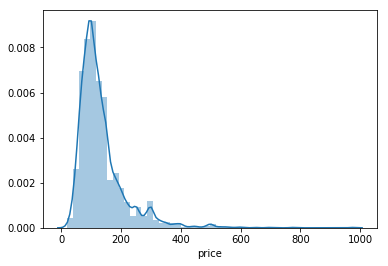

```python
sns.distplot(airbnb['price']);
```

### Figure1:

```python
def daily_revenue(airbnb):
    if airbnb['guests_included'] > 1:
        return airbnb['price']
    elif (airbnb['guests_included'] == 1) and (airbnb['accommodates']==1):
        return airbnb['price']
    elif (airbnb['guests_included']==1) and (airbnb['accommodates'] > 1):
        airbnb['price'] += airbnb['extra_people']
        return airbnb['price']

#     # added beside the request for any guests_included more than accommodates allowed for same price :
#     elif (airbnb['accommodates'] > airbnb['guests_included']):
#         airbnb['price'] += airbnb['extra_people'] * (airbnb['accommodates'] - airbnb['guests_included'] )
#         return airbnb['price']
#     return airbnb['price']
```

```python
airbnb['stays'] = airbnb['number_of_reviews'] * 2 #prompt1 step-1
airbnb['revenue']= airbnb.apply(daily_revenue , axis=1) #prompt1 step-2
airbnb['revenue_per_booking'] = airbnb['revenue'] * airbnb['minimum_nights'] #prmpt1 step-3
airbnb['total_revenue'] = airbnb['revenue_per_booking'] * airbnb['stays'] #prompt1 step-4
```

```python
airbnb_prompt_1 = airbnb[['id','number_of_reviews', 'stays','guests_included','price', 'extra_people',\
'accommodates','revenue','minimum_nights','revenue_per_booking','total_revenue']]

airbnb_prompt_1.sort_values('id')
```

|  | id | number_of_reviews | stays | guests_included | price | extra_people | accommodates | revenue | minimum_nights | revenue_per_booking | total_revenue |
| --- | --- | --- | --- | --- | --- | --- | --- | --- | --- | --- | --- |
| 1647 | 3351 | 1 | 2 | 1 | 60.0 | 10.0 | 2 | 70.0 | 1 | 70.0 | 140.0 |
| 30 | 3362 | 94 | 188 | 2 | 250.0 | 125.0 | 4 | 250.0 | 1 | 250.0 | 47000.0 |
| 619 | 3577 | 36 | 72 | 5 | 290.0 | 50.0 | 7 | 290.0 | 2 | 580.0 | 41760.0 |
| 1922 | 3662 | 25 | 50 | 1 | 75.0 | 25.0 | 3 | 100.0 | 2 | 200.0 | 10000.0 |
| 1590 | 3663 | 21 | 42 | 2 | 140.0 | 0.0 | 5 | 140.0 | 2 | 280.0 | 11760.0 |
| 1368 | 3670 | 16 | 32 | 1 | 95.0 | 0.0 | 1 | 95.0 | 2 | 190.0 | 6080.0 |
| 1938 | 3686 | 60 | 120 | 1 | 65.0 | 15.0 | 2 | 80.0 | 1 | 80.0 | 9600.0 |
| 2607 | 3943 | 311 | 622 | 1 | 89.0 | 15.0 | 2 | 104.0 | 2 | 208.0 | 129376.0 |
| 1531 | 4002 | 119 | 238 | 4 | 150.0 | 25.0 | 9 | 150.0 | 2 | 300.0 | 71400.0 |
| 2493 | 4283 | 9 | 18 | 3 | 160.0 | 15.0 | 4 | 160.0 | 7 | 1120.0 | 20160.0 |
| 496 | 4501 | 120 | 240 | 1 | 99.0 | 50.0 | 1 | 99.0 | 2 | 198.0 | 47520.0 |
| 2632 | 4520 | 2 | 4 | 1 | 60.0 | 20.0 | 6 | 80.0 | 2 | 160.0 | 640.0 |
| 750 | 4529 | 67 | 134 | 2 | 60.0 | 5.0 | 2 | 60.0 | 1 | 60.0 | 8040.0 |
| 2652 | 4967 | 26 | 52 | 1 | 99.0 | 0.0 | 1 | 99.0 | 2 | 198.0 | 10296.0 |
| 2391 | 5589 | 46 | 92 | 1 | 95.0 | 20.0 | 4 | 115.0 | 2 | 230.0 | 21160.0 |
| 1693 | 6165 | 20 | 40 | 2 | 140.0 | 0.0 | 2 | 140.0 | 2 | 280.0 | 11200.0 |
| 710 | 7103 | 75 | 150 | 2 | 89.0 | 10.0 | 3 | 89.0 | 4 | 356.0 | 53400.0 |
| 1833 | 7202 | 4 | 8 | 1 | 80.0 | 0.0 | 2 | 80.0 | 1 | 80.0 | 640.0 |
| 2951 | 8882 | 206 | 412 | 2 | 118.0 | 0.0 | 2 | 118.0 | 2 | 236.0 | 97232.0 |
| 1506 | 8919 | 46 | 92 | 1 | 85.0 | 10.0 | 2 | 95.0 | 10 | 950.0 | 87400.0 |
| 2436 | 9097 | 39 | 78 | 1 | 45.0 | 20.0 | 1 | 45.0 | 1 | 45.0 | 3510.0 |
| 3671 | 9546 | 85 | 170 | 1 | 120.0 | 10.0 | 2 | 130.0 | 1 | 130.0 | 22100.0 |
| 1140 | 9641 | 65 | 130 | 2 | 215.0 | 35.0 | 2 | 215.0 | 2 | 430.0 | 55900.0 |
| 3244 | 10582 | 105 | 210 | 6 | 203.0 | 25.0 | 9 | 203.0 | 3 | 609.0 | 127890.0 |
| 3622 | 10766 | 51 | 102 | 1 | 95.0 | 20.0 | 2 | 115.0 | 3 | 345.0 | 35190.0 |
| 3334 | 11785 | 237 | 474 | 4 | 113.0 | 35.0 | 6 | 113.0 | 1 | 113.0 | 53562.0 |
| 3339 | 12442 | 8 | 16 | 1 | 69.0 | 25.0 | 2 | 94.0 | 1 | 94.0 | 1504.0 |
| 3311 | 14218 | 18 | 36 | 1 | 69.0 | 25.0 | 3 | 94.0 | 1 | 94.0 | 3384.0 |
| 162 | 14570 | 338 | 676 | 1 | 85.0 | 12.0 | 3 | 97.0 | 3 | 291.0 | 196716.0 |
| 2460 | 16641 | 50 | 100 | 2 | 165.0 | 35.0 | 3 | 165.0 | 2 | 330.0 | 33000.0 |

[output cut: 471 more lines]

2565 rows × 11 columns

**1. What is the total revenue for each host?**

```python
best_host=airbnb.groupby('host_name')['total_revenue'].sum().sort_values(ascending=False).\
head(20).reset_index(name='Total Revenue')
print(best_host)
```

```
        host_name  Total Revenue
0         Hermosa       923036.0
1           Cliff       659640.0
2       Charlotte       658616.0
3           Gohar       490140.0
4         Jessica       432966.0
5         Heather       393848.0
6        Seamless       381958.0
7   Matt And Jean       329850.0
8             Art       312840.0
9    Leslie & Joe       312052.0
10    Lara & Alex       295764.0
11           Adam       260700.0
12          David       252622.0
13          Ethan       248370.0
14           John       246334.0
15          Emily       238166.0
16       Sunshine       235700.0
17          Chris       215864.0
18            Ken       206280.0
19          Bryan       204004.0
```

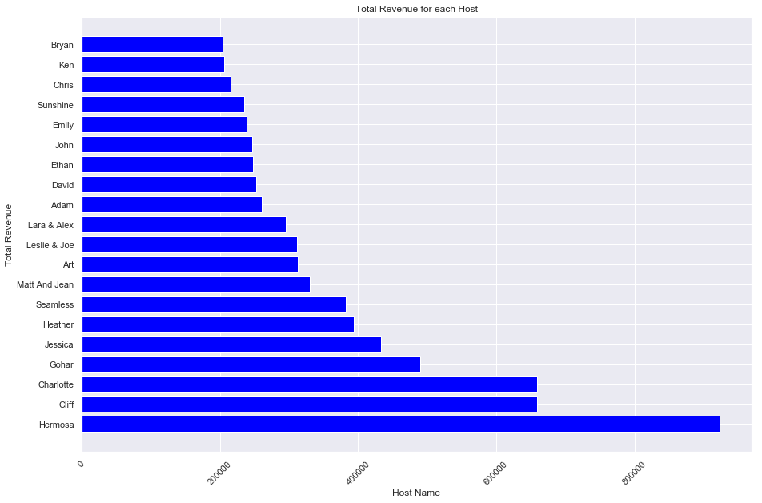

```python
plt.barh(best_host.iloc[:,0],best_host.iloc[:,1],color=['blue'])
plt.xlabel('Host Name')
plt.ylabel('Total Revenue')
plt.title('Total Revenue for each Host')
plt.xticks(rotation=45)
plt.show()
```

### Figure2:

in conclusion : the total revenue for each host showed that The host : `Hermosa` is givinig the highest revenue in 2015.

**2.What is the average price for different room types?**

```
         room_type       price
0  Entire home/apt  159.910187
1     Private room   86.854762
2      Shared room   57.742424
```

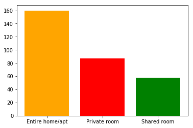

```python
average_price = airbnb[['room_type', 'price']].groupby(['room_type'], as_index=False).mean().sort_values(by='price',ascending=False)
print(average_price)
plt.bar(average_price.iloc[:,0],average_price.iloc[:,1],color=['orange','red','green'])
plt.show()
```

### Figure3:

in conclusion : Entire home/apt has the highest average price comparing to other room type .

```python
grouped_room_type=airbnb.groupby(['neighbourhood','room_type'])['total_revenue'].mean().head(20).reset_index(name='average_revenue')
grouped_room_type
```

|  | neighbourhood | room_type | average_revenue |
| --- | --- | --- | --- |
| 0 | 16th Street Heights | Entire home/apt | 6877.090909 |
| 1 | 16th Street Heights | Private room | 3699.454545 |
| 2 | 16th Street Heights | Shared room | 88.000000 |
| 3 | Adams Morgan | Entire home/apt | 8646.625000 |
| 4 | Adams Morgan | Private room | 6578.153846 |
| 5 | Adams Morgan | Shared room | 4858.222222 |
| 6 | American University Park | Entire home/apt | 22291.500000 |
| 7 | American University Park | Private room | 895.666667 |
| 8 | Anacostia | Entire home/apt | 3980.000000 |
| 9 | Anacostia | Private room | 5197.545455 |
| 10 | Barney Circle | Entire home/apt | 16116.857143 |
| 11 | Barney Circle | Private room | 8864.285714 |
| 12 | Bellevue | Entire home/apt | 1880.000000 |
| 13 | Benning | Entire home/apt | 24940.000000 |
| 14 | Benning | Private room | 4600.000000 |
| 15 | Benning Heights | Entire home/apt | 40800.000000 |
| 16 | Berkley | Entire home/apt | 26866.666667 |
| 17 | Bloomingdale | Entire home/apt | 11224.000000 |
| 18 | Bloomingdale | Private room | 39543.481481 |
| 19 | Brentwood | Entire home/apt | 3439.600000 |

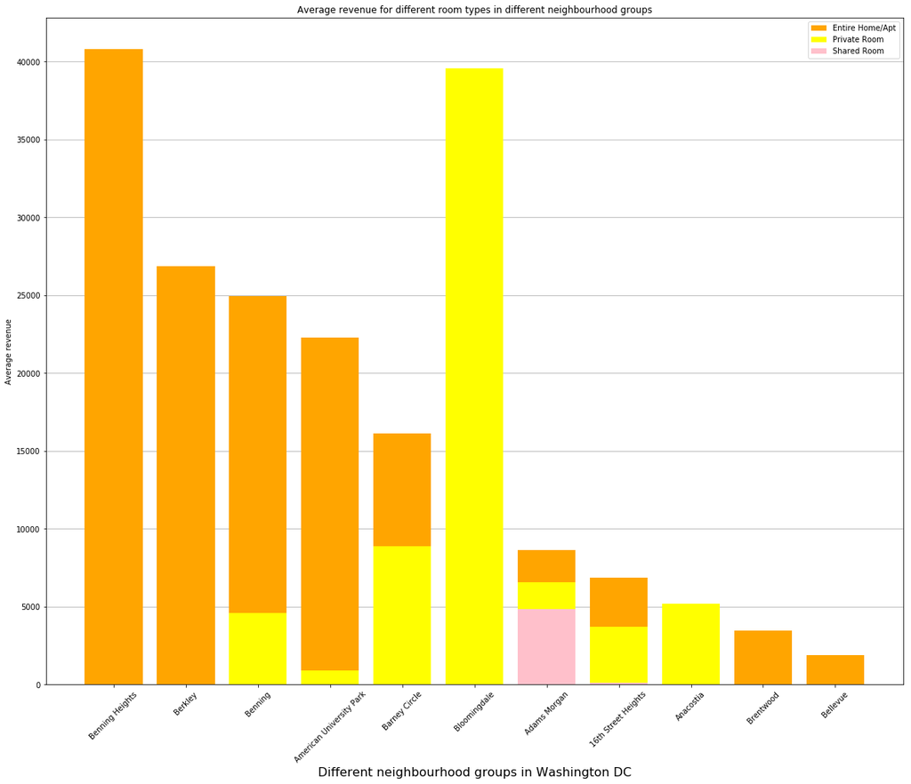

```python
Entirehome=grouped_room_type.loc[grouped_room_type['room_type']=='Entire home/apt'].sort_values(by='average_revenue',ascending=False)
Privateroom=grouped_room_type.loc[grouped_room_type['room_type']=='Private room']
Sharedroom=grouped_room_type.loc[grouped_room_type['room_type']=='Shared room']
plt.bar(Entirehome.iloc[:,0],Entirehome.iloc[:,2],label='Entire Home/Apt',color='orange',zorder=2)
plt.bar(Privateroom.iloc[:,0],Privateroom.iloc[:,2],label='Private Room',color='yellow',zorder=2)
plt.bar(Sharedroom.iloc[:,0],Sharedroom.iloc[:,2],label='Shared Room',color='pink',zorder=2)
plt.legend()
plt.rcParams['figure.figsize'] = (17,20)
plt.xticks(rotation=45)
plt.xlabel('Different neighbourhood groups in Washington DC',fontsize=16)
plt.ylabel('Average revenue')
plt.title('Average revenue for different room types in different neighbourhood groups')
plt.grid(axis='y')
plt.show()
```

## Property reviews — Which property types receive the most positive reviews?

an overview of the number of reivews in each property type

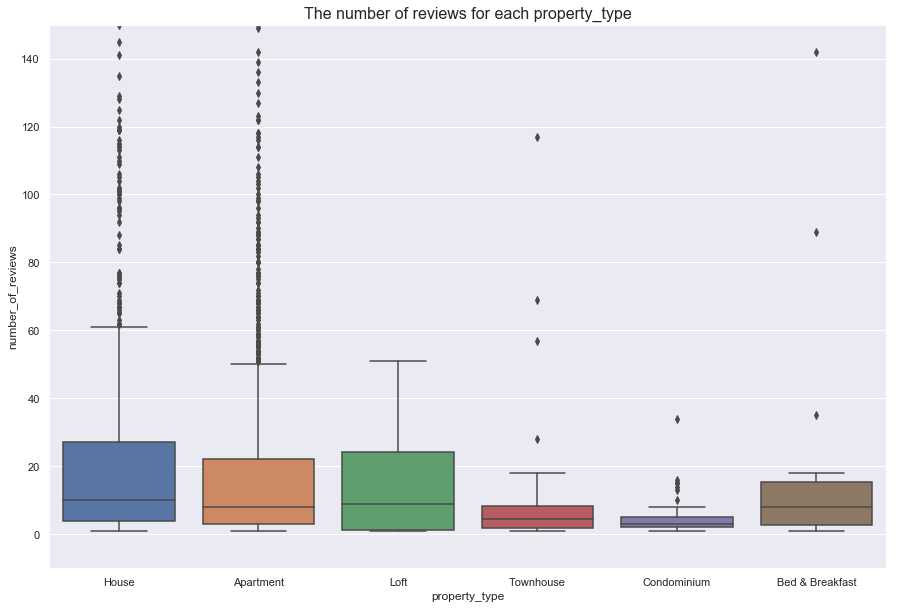

```python
subset_airbnb = airbnb[~airbnb['property_type'].isin(["Dorm","Bungalow","Cabin","Other"])]
sns.set(rc={"figure.figsize":(15,10)})
sns_plot=sns.boxplot(x="property_type", y="number_of_reviews" ,data=subset_airbnb )
plt.title("The number of reviews for each property_type", fontsize=16);
plt.ylabel('number_of_reviews'),plt.xlabel('property_type')
plt.ylim(-10,150);
```

### Figure5:

The groupby of property type by the total number of reivews and the total mean for review scores

```python
groupby_property = airbnb.groupby(['property_type']).agg({'number_of_reviews':"sum",'review_scores_rating': 'mean'}).\
rename(columns = {'review_scores_rating' : 'review_scores_rating','number_of_reviews': 'number_of_reviews'}).reset_index(). \
sort_values('number_of_reviews', ascending=False)[:5]
groupby_property.head(5)
```

|  | property_type | number_of_reviews | review_scores_rating |
| --- | --- | --- | --- |
| 0 | Apartment | 28397 | 93.317685 |
| 6 | House | 20075 | 93.530233 |
| 1 | Bed & Breakfast | 1016 | 91.406250 |
| 9 | Townhouse | 470 | 95.090909 |
| 4 | Condominium | 381 | 95.511111 |

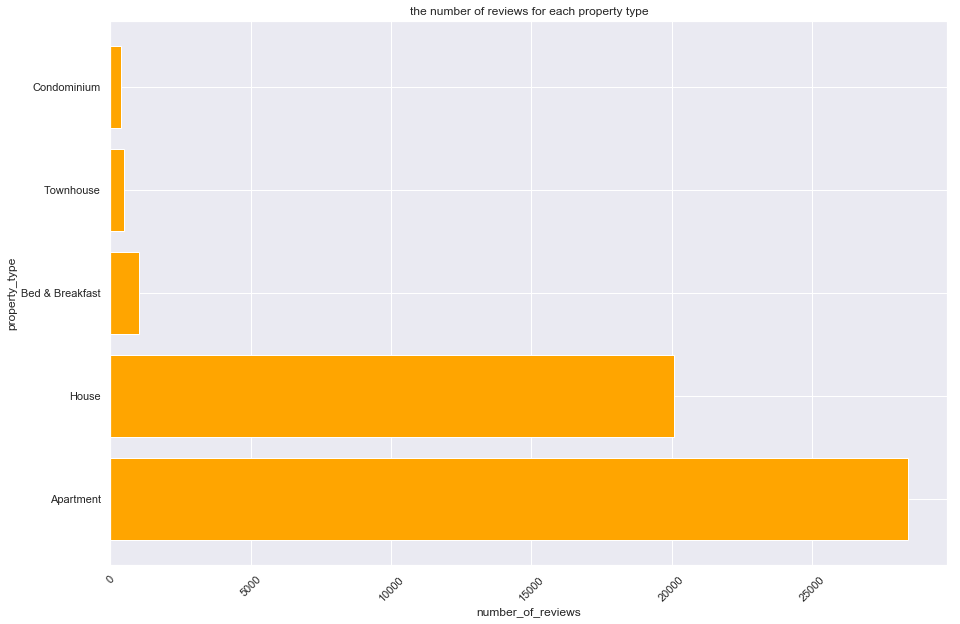

```python
plt.barh(groupby_property.iloc[:,0],groupby_property.iloc[:,1],color=['orange'])
plt.xlabel('number_of_reviews')
plt.ylabel('property_type')
plt.title('the number of reviews for each property type')
plt.xticks(rotation=45)
plt.show()
```

### Figure6:

in conclusion : Apartment and house are the most popular proterty type based on number of review. However, the highest score rating from reviews is for property type called condominium .

## Neighborhood popularity — Which neighborhoods host the most listings?

```python
counts = airbnb.groupby(['neighbourhood']).size().sort_values(ascending=False).head(12).reset_index(name='counts')
print(counts)
```

```
                       neighbourhood  counts
0                       Capitol Hill     237
1                   Columbia Heights     187
2                      Dupont Circle     153
3                       Logan Circle     140
4                  U Street Corridor     133
5                       Adams Morgan     102
6   Near Northeast/H Street Corridor      93
7                               Shaw      92
8                         Georgetown      65
9                     Mount Pleasant      62
10                          Petworth      61
11               Mount Vernon Square      57
```

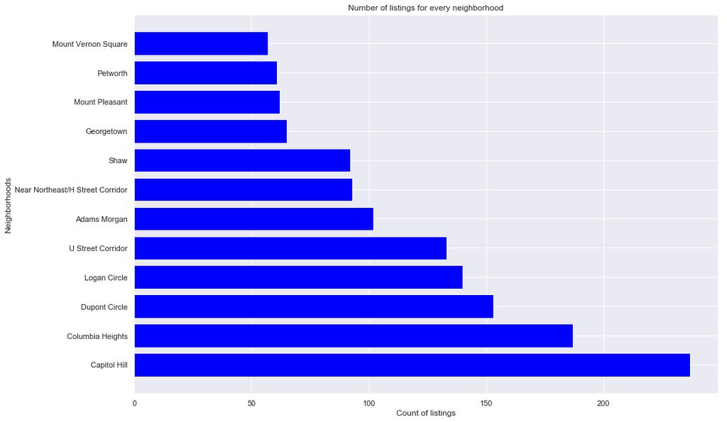

```python
plt.barh(counts.iloc[:,0],counts.iloc[:,1],color=['blue'])
plt.xlabel('Count of listings')
plt.ylabel('Neighborhoods')
plt.title('Number of listings for every neighborhood')
plt.xticks(rotation=0)
plt.show()
```

### Figure7:

In conclusion : The Captial Hill has the most listing

## Neighborhood sentiment — Which neighborhoods receive the most positive reviews?

```python
best_neighbourhood=airbnb.groupby('neighbourhood')['review_scores_value'].mean()\
.sort_values(ascending=False).head(12).reset_index(name='Review Average')

print(best_neighbourhood)
```

```
         neighbourhood  Review Average
0             Douglass       10.000000
1           Fort Davis       10.000000
2             Woodland       10.000000
3       Wesley Heights       10.000000
4             Bellevue       10.000000
5     Garfield Heights       10.000000
6             Greenway       10.000000
7   Friendship Heights        9.857143
8            Palisades        9.833333
9     Marshall Heights        9.800000
10             Foxhall        9.750000
11         Glover Park        9.681818
```

### Summary

[figure not shown]

# Thanks Misk Academy & Udacity

[figure not shown]